# ML project

Henry

July 9, 2017

## R Markdown

### Data initialization and cleaning

The data came from “https://d396qusza40orc.cloudfront.net/predmachlearn/pml-training.csv”.

```r
training<-read.csv("pml_training.csv",header = TRUE,row.names = 1,
                   na.strings = c("","NA","#DIV/0!"))
summary(training$classe)
```

```
##    A    B    C    D    E
## 5580 3797 3422 3216 3607
```

```r
summary(training$user_name)
```

```
##   adelmo carlitos  charles   eurico   jeremy    pedro
##     3892     3112     3536     3070     3402     2610
```

The data is loaded from the csv files using settings for the row names and the missing variables. There are 5 classes of outcomes A-E, although B-E are incorrect performances of different kinds. There were 6 participants.

```r
sum(sapply(training,FUN = function(x) any(is.na(x))))
```

```
## [1] 100
```

```r
training$cvtd_timestamp<-strptime(training$cvtd_timestamp,format="%d/%m/%Y %H:%M")
training.1<-training[,sapply(training,FUN = function(x) !any(is.na(x)))]
training.1<-training.1[,-c(1:6)]
```

There are 100 variables which contain missing observations. Many of these are summary variables for all of the points in a window, like kurtosis and skewness. These were dropped from the data. I subset the data into training and cross- validation sets. This way I can compare the accuracy of several models/parameters.

```r
set.seed(42)
Index = createDataPartition(training.1$classe, p = 0.30,list=FALSE)
train = training.1[-Index,]
crossval = training.1[Index,]
```

First I tried multinominal regression, which is logistic regression with several class outcomes.

```r
mod <- multinom(classe ~ ., train)
probs<-predict(mod,crossval,type = "probs")
preds<-apply(probs,MARGIN = 1,FUN = function(x) which.max(x))
predictions<-ifelse(preds==1,"A",ifelse(preds==2,"B",ifelse(preds==3,"C",
                              ifelse(preds==4,"D","E"))))
confusionMatrix(crossval$classe,predictions)
```

```
## Confusion Matrix and Statistics
##
##           Reference
## Prediction    A    B    C    D    E
##          A 1403   42   80  111   38
##          B  173  604  146   95  122
##          C  120   89  576  137  105
##          D  106   57   77  690   35
##          E   61  140   78  168  636
##
## Overall Statistics
##
##                Accuracy : 0.6638
##                  95% CI : (0.6516, 0.6758)
##     No Information Rate : 0.3164
##     P-Value [Acc > NIR] : < 2.2e-16
##
##                   Kappa : 0.5736
##  Mcnemar's Test P-Value : < 2.2e-16
##
## Statistics by Class:
##
##                      Class: A Class: B Class: C Class: D Class: E
## Sensitivity            0.7531   0.6481  0.60188   0.5745   0.6795
## Specificity            0.9327   0.8919  0.90856   0.9413   0.9098
## Pos Pred Value         0.8381   0.5298  0.56086   0.7150   0.5873
## Neg Pred Value         0.8909   0.9309  0.92164   0.8962   0.9376
## Prevalence             0.3164   0.1583  0.16251   0.2039   0.1589
## Detection Rate         0.2382   0.1026  0.09781   0.1172   0.1080
## Detection Prevalence   0.2843   0.1936  0.17439   0.1639   0.1839
## Balanced Accuracy      0.8429   0.7700  0.75522   0.7579   0.7946
```

The overall accuracy of this method was 66% on the cross-validation set. I may be able to improve this by adjusting the parameters, interaction terms, and/or creating new varaiables. However, random forest is really good at this type of classification.

I start with 100 trees and plot the error. Since the error drops to the low point at the end, I will stick with the default of 500 trees for the model.

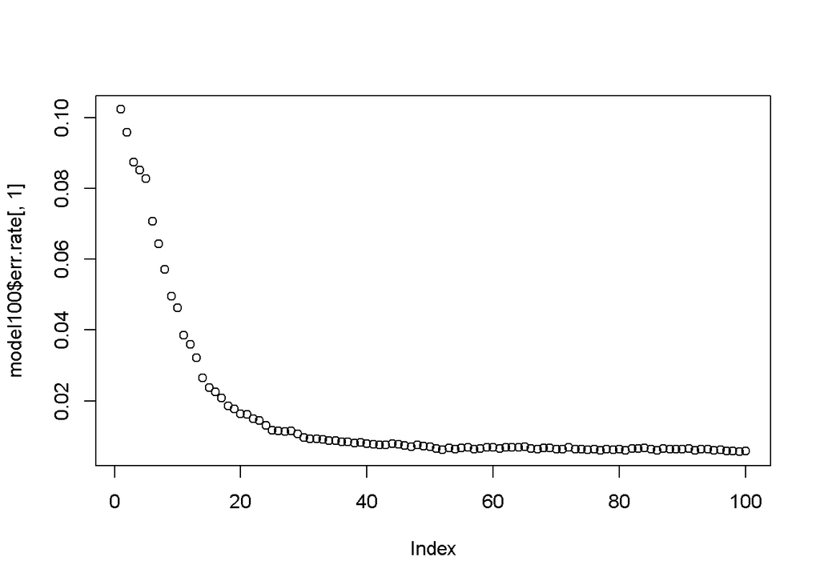

```r
model100 <- randomForest(classe ~.,data=train,ntree=100)
plot(model100$err.rate[,1])
```

```r
model <- randomForest(classe ~.,data=train)
predictions.rf<-predict(model,crossval)
confusionMatrix(crossval$classe,predictions.rf)
```

```
## Confusion Matrix and Statistics
##
##           Reference
## Prediction    A    B    C    D    E
##          A 1672    1    0    0    1
##          B    5 1132    3    0    0
##          C    0    9 1018    0    0
##          D    0    0   14  951    0
##          E    0    0    2    0 1081
##
## Overall Statistics
##
##                Accuracy : 0.9941
##                  95% CI : (0.9917, 0.9959)
##     No Information Rate : 0.2848
##     P-Value [Acc > NIR] : < 2.2e-16
##
##                   Kappa : 0.9925
##  Mcnemar's Test P-Value : NA
##
## Statistics by Class:
##
##                      Class: A Class: B Class: C Class: D Class: E
## Sensitivity            0.9970   0.9912   0.9817   1.0000   0.9991
## Specificity            0.9995   0.9983   0.9981   0.9972   0.9996
## Pos Pred Value         0.9988   0.9930   0.9912   0.9855   0.9982
## Neg Pred Value         0.9988   0.9979   0.9961   1.0000   0.9998
## Prevalence             0.2848   0.1939   0.1761   0.1615   0.1837
## Detection Rate         0.2839   0.1922   0.1729   0.1615   0.1836
## Detection Prevalence   0.2843   0.1936   0.1744   0.1639   0.1839
## Balanced Accuracy      0.9983   0.9948   0.9899   0.9986   0.9993
```

The accuracy of this model is over 99%. The rf model used 7 variables for each tree. It would be informative to know which features are actually important for the prediction.

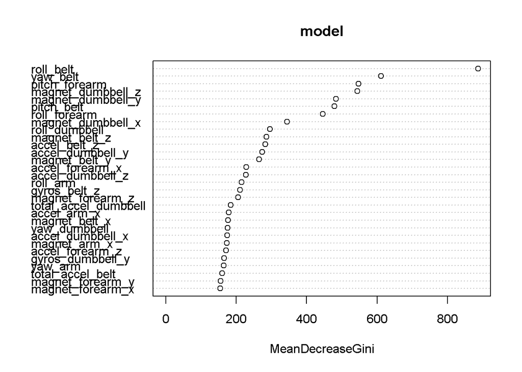

```r
vip<-varImp(object = model)
varImpPlot(model)
```

The first ~20 variables are important, while the rest have equally low scores. I subset the training data to those features only. I then train the random forest using the full data since random forest uses a form of cross-validation internally.

```r
vip20<-rownames(vip)[order(vip$Overall,decreasing = TRUE)][1:20]
training.2<-training.1[,c(vip20,"classe")]
model2 <- randomForest(classe ~.,data=training.2)
model2
```

```
##
## Call:
##  randomForest(formula = classe ~ ., data = training.2)
##                Type of random forest: classification
##                      Number of trees: 500
## No. of variables tried at each split: 4
##
##         OOB estimate of  error rate: 0.38%
## Confusion matrix:
##      A    B    C    D    E  class.error
## A 5576    3    0    0    1 0.0007168459
## B   10 3772   15    0    0 0.0065841454
## C    0    9 3407    6    0 0.0043834015
## D    0    0   19 3194    3 0.0068407960
## E    0    0    3    6 3598 0.0024951483
```

The final model has an out of bag estimated error of 0.38%, which is slightly less than the error in the previous model.